# Tugas Penanganan Autokorelasi

M.Taqy Abiyu Dzakwan

2025-08-29

# Library

```r
library(readxl)
library(lmtest)
#install.packages("https://cran.r-project.org/src/contrib/Archive/orcutt/orcutt_2.0.tar.gz", repos = NULL, type = "source")
library(orcutt)
```

# Data Preparation

```r
data <- read_excel("D:\\TUGAS IPB\\Semester 5\\mpdw\\Pertemuan 2\\Data\\Data IPM.xlsx")
head(data)
```

```
## # A tibble: 6 × 2
##   Tahun   IPM
##   <dbl> <dbl>
## 1  2010  63.7
## 2  2011  64.2
## 3  2012  64.9
## 4  2013  65.7
## 5  2014  66.4
## 6  2015  67.0
```

```r
dim(data)
```

```
## [1] 15  2
```

# Data Eksploration

```r
data.ts<-ts(data$IPM)
data.ts
```

```
## Time Series:
## Start = 1
## End = 15
## Frequency = 1
##  [1] 63.71 64.20 64.87 65.73 66.42 66.95 67.65 68.25 69.02 69.57 69.69 69.90
## [13] 70.45 71.15 71.81
```

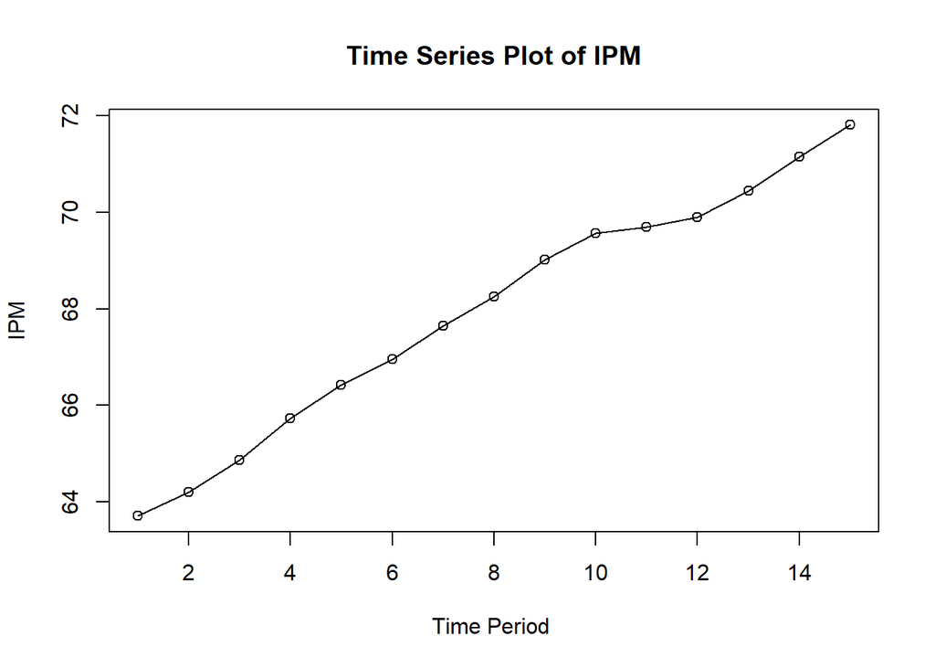

```r
ts.plot(data.ts, xlab="Time Period ", ylab="IPM", main= "Time Series Plot of IPM")
points(data.ts)
```

Secara umum, grafik deret waktu IPM menunjukkan adanya **tren meningkat dari waktu ke waktu**, di mana nilai IPM terus bertambah secara bertahap tanpa adanya pola musiman atau fluktuasi besar. Hal ini mengindikasikan adanya perkembangan positif dan pertumbuhan yang relatif stabil sepanjang periode pengamatan.

# Regresi

```r
regres <- lm(IPM ~ Tahun, data = data)
summary(regres)
```

```
##
## Call:
## lm(formula = IPM ~ Tahun, data = data)
##
## Residuals:
##      Min       1Q   Median       3Q      Max
## -0.35443 -0.25229  0.02414  0.21557  0.49271
##
## Coefficients:
##               Estimate Std. Error t value Pr(>|t|)
## (Intercept) -1.080e+03  3.692e+01  -29.26 2.99e-13 ***
## Tahun        5.693e-01  1.831e-02   31.10 1.37e-13 ***
## ---
## Signif. codes:  0 '***' 0.001 '**' 0.01 '*' 0.05 '.' 0.1 ' ' 1
##
## Residual standard error: 0.3063 on 13 degrees of freedom
## Multiple R-squared:  0.9867, Adjusted R-squared:  0.9857
## F-statistic: 967.2 on 1 and 13 DF,  p-value: 1.369e-13
```

```r
dwtest(regres)
```

```
##
##  Durbin-Watson test
##
## data:  regres
## DW = 0.43648, p-value = 4.693e-06
## alternative hypothesis: true autocorrelation is greater than 0
```

Pada hasil dapat diketahui bahwa terdapat autokorelasi dikarenakan nilai hasil uji DW berada di luar rentang DU < DW < 4-DU atau $1.3605 < DW < 2.6395$. Diperkuat juga nilai p-value yang kurang dari 0.05 sehingga menolak H0 yang mana berarti ada autokorelasi.

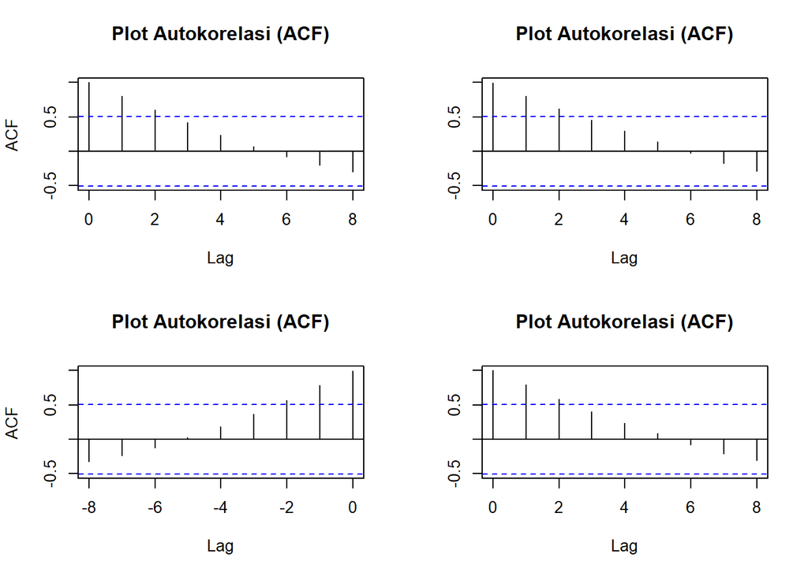

```r
acf(data, main = "Plot Autokorelasi (ACF)")
```

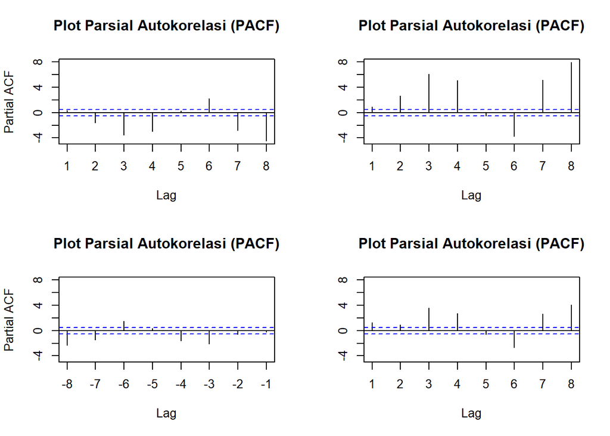

```r
pacf(data, main = "Plot Parsial Autokorelasi (PACF)")
```

# Penanganan Autokorelasi

## Metode Cochrane Orcutt

### Pakai package

```r
modelCO<-cochrane.orcutt(regres)
modelCO
```

```
## Cochrane-orcutt estimation for first order autocorrelation
##
## Call:
## lm(formula = IPM ~ Tahun, data = data)
##
##  number of interaction: 25
##  rho 0.76584
##
## Durbin-Watson statistic
## (original):    0.43648 , p-value: 4.693e-06
## (transformed): 1.10911 , p-value: 1.427e-02
##
##  coefficients:
## (Intercept)       Tahun
## -976.439847    0.517918
```

Hasil keluaran model setelah dilakukan penanganan adalah sebagai berikut.
$$y_i=-976.439847+0.517918x_t$$
Hasil Durbin Watson meningkat dari $0.43648$ menjadi $1.10911$ setelah koreksi. Meskipun nilai DW mengalami perbaikan, hasil *hasil belum berada pada rentang non-autokorelasi* pada DU < DW < 4-DU atau $1.3605 < DW < 2.6395$. Hal tersebut juga didukung dengan nilai *p-value* < 0.05, artinya cukup bukti untuk menyatakan bahwa sisaan terdapat autokorelasi pada taraf nyata 5%. Sehingga metode ini masih belum bisa menangani Autokorelasinya. sebagai tambahan informasi Untuk nilai $ρ ̂$ optimum yang digunakan adalah $0.76584$. Nilai tersebut dapat diketahui dengan *syntax* berikut.

```r
rho <- modelCO$rho
rho
```

```
## [1] 0.7658402
```

### Transformasi Manual

```r
IPM <- data$IPM
Tahun <- data$Tahun
y.transformed <- IPM[-1] - (IPM[-24] * rho)
x.transformed <- Tahun[-1] - (Tahun[-24] * rho)
model.t <- lm(y.transformed ~ x.transformed)
summary(model.t)
```

```
##
## Call:
## lm(formula = y.transformed ~ x.transformed)
##
## Residuals:
##      Min       1Q   Median       3Q      Max
## -0.37237 -0.09362  0.02210  0.11223  0.26067
##
## Coefficients:
##                 Estimate Std. Error t value Pr(>|t|)
## (Intercept)   -259.90412    7.39934  -35.12 2.86e-14 ***
## x.transformed    0.58397    0.01566   37.28 1.33e-14 ***
## ---
## Signif. codes:  0 '***' 0.001 '**' 0.01 '*' 0.05 '.' 0.1 ' ' 1
##
## Residual standard error: 0.1934 on 13 degrees of freedom
## Multiple R-squared:  0.9907, Adjusted R-squared:   0.99
## F-statistic:  1390 on 1 and 13 DF,  p-value: 1.328e-14
```

### Mencari Penduga Koefisien Regresi setelah Transformasi ke Persamaan Awal

```r
b0bintang <- model.t$coefficients[-2]
b0 <- b0bintang/(1-rho)
b1 <- model.t$coefficients[-1]
b0bintang
```

```
## (Intercept)
##   -259.9041
```

```r
b0
```

```
## (Intercept)
##   -1109.943
```

```r
b1
```

```
## x.transformed
##     0.5839735
```

## Metode Hildreth-Lu

```r
hildreth.lu.func<- function(r, regres){
  x <- model.matrix(regres)[,-1]
  y <- model.response(model.frame(regres))
  n <- length(y)
  t <- 2:n
  y <- y[t]-r*y[t-1]
  x <- x[t]-r*x[t-1]

  return(lm(y~x))
}
```

### Pencarian rho yang meminimumkan SSE

```r
r <- c(seq(0.1,0.9, by= 0.1))
tab <- data.frame("rho" = r, "SSE" = sapply(r, function(i){deviance(hildreth.lu.func(i, regres))}))
round(tab, 4)
```

```
##   rho    SSE
## 1 0.1 0.9572
## 2 0.2 0.8098
## 3 0.3 0.6864
## 4 0.4 0.5869
## 5 0.5 0.5113
## 6 0.6 0.4597
## 7 0.7 0.4320
## 8 0.8 0.4282
## 9 0.9 0.4483
```

```r
rOpt <- seq(0.6,0.9, by= 0.001)
tabOpt <- data.frame("rho" = rOpt, "SSE" = sapply(rOpt, function(i){deviance(hildreth.lu.func(i, regres))}))
head(tabOpt[order(tabOpt$SSE),])
```

```
##       rho       SSE
## 167 0.766 0.4268003
## 166 0.765 0.4268011
## 168 0.767 0.4268019
## 165 0.764 0.4268043
## 169 0.768 0.4268058
## 164 0.763 0.4268099
```

Perhitungan menunjukkan bahwa nilai $ρ$ optimum, yaitu saat SSE terkecil terdapat pada nilai $ρ=0.766$.

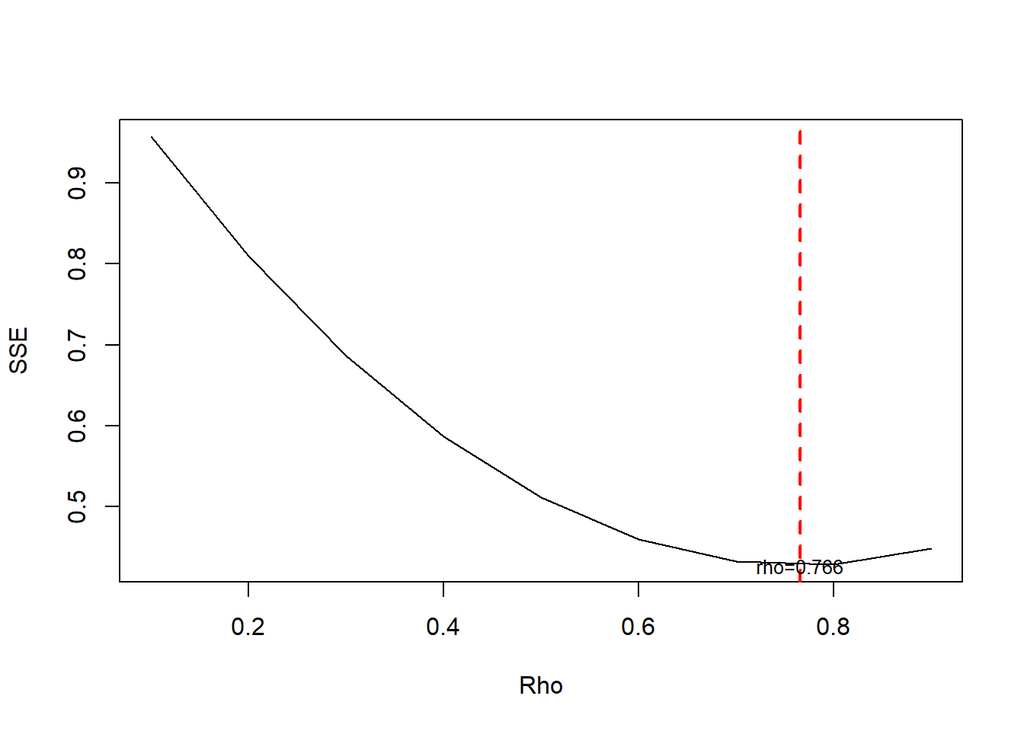

```r
par(mfrow = c(1,1))
plot(tab$SSE ~ tab$rho , type = "l", xlab = "Rho", ylab = "SSE")
abline(v = tabOpt[tabOpt$SSE==min(tabOpt$SSE),"rho"], lty = 2, col="red",lwd=2)
text(x=0.766, y=0.4268003, labels = "rho=0.766", cex = 0.8)
```

```r
modelHL <- hildreth.lu.func(0.766, regres)
summary(modelHL)
```

```
##
## Call:
## lm(formula = y ~ x)
##
## Residuals:
##      Min       1Q   Median       3Q      Max
## -0.32304 -0.05656  0.07647  0.10442  0.26355
##
## Coefficients:
##               Estimate Std. Error t value Pr(>|t|)
## (Intercept) -228.46888   25.26676  -9.042 1.05e-06 ***
## x              0.51788    0.05343   9.692 5.02e-07 ***
## ---
## Signif. codes:  0 '***' 0.001 '**' 0.01 '*' 0.05 '.' 0.1 ' ' 1
##
## Residual standard error: 0.1886 on 12 degrees of freedom
## Multiple R-squared:  0.8867, Adjusted R-squared:  0.8773
## F-statistic: 93.94 on 1 and 12 DF,  p-value: 5.016e-07
```

```r
cat("y = ", coef(modelHL)[1]/(1-0.766), "+", coef(modelHL)[2],"x", sep = "")
```

```
## y = -976.3627+0.51788x
```

Setelah dilakukan tranformasi balik, didapatkan model dengan metode Hildreth-Lu sebagai berikut.
$$y_i=-976.3627+0.51788x_t$$

```r
dwtest(modelHL)
```

```
##
##  Durbin-Watson test
##
## data:  modelHL
## DW = 1.1092, p-value = 0.01428
## alternative hypothesis: true autocorrelation is greater than 0
```

# Perbandingan nilai SSE 3 metode

Terakhir, akan dibandingkan nilai SSE dari ketiga metode (metode awal, metode Cochrane-Orcutt, dan Hildreth-Lu).

```r
sseModelawal <- anova(regres)$`Sum Sq`[-1]
sseModelCO <- anova(model.t)$`Sum Sq`[-1]
sseModelHL <- anova(modelHL)$`Sum Sq`[-1]
mseModelawal <- sseModelawal/length(IPM)
mseModelCO <- sseModelCO/length(IPM)
mseModelHL <- sseModelHL/length(IPM)
akurasi <- matrix(c(sseModelawal,sseModelCO,sseModelHL,
                    mseModelawal,mseModelCO,mseModelHL),nrow=2,ncol=3,byrow = T)
colnames(akurasi) <- c("Model Awal", "Model Cochrane-Orcutt", "Model Hildreth-Lu")
row.names(akurasi) <- c("SSE","MSE")
akurasi
```

```
##     Model Awal Model Cochrane-Orcutt Model Hildreth-Lu
## SSE 1.21969714            0.48608090        0.42680029
## MSE 0.08131314            0.03240539        0.02845335
```

Berdasarkan hasil tersebut dapat diketahui bahwa penanganan autokorelasi dengan metode Cochrane–Orcutt dan Hildreth–Lu mampu menurunkan nilai SSE dan MSE dibandingkan model awal. Nilai SSE model awal adalah $1.21969714$ dengan MSE $0.08131314$, sedangkan pada model Cochrane–Orcutt nilai SSE turun menjadi $0.48608090$ dengan MSE $0.03240539$. Model Hildreth–Lu memberikan hasil yang lebih baik lagi dengan SSE sebesar $0.42680029$ dan MSE sebesar $0.02845335$. Walau keduanya telah berhasil menurunkan nilai MSE dan SSE tetapi keduanya belum berhasil menghilangkan autokorelasi pada data.